# Lecture 07: Charts

### Demo: Male and Female 2019 Estimates

Create a table with `Age`, `Males`, `Females` columns showing the population estimates in 2019 for males and females by age.

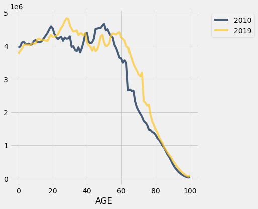

```python
everyone.plot('AGE', ['2010', '2019'])
```

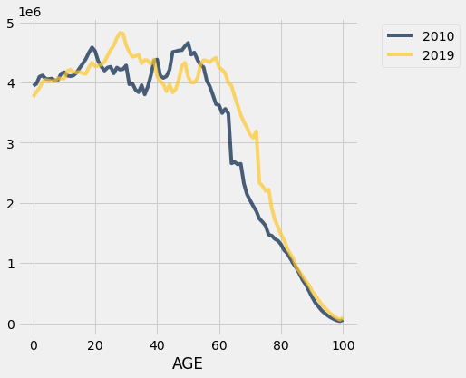

```python
everyone.plot('AGE')
```

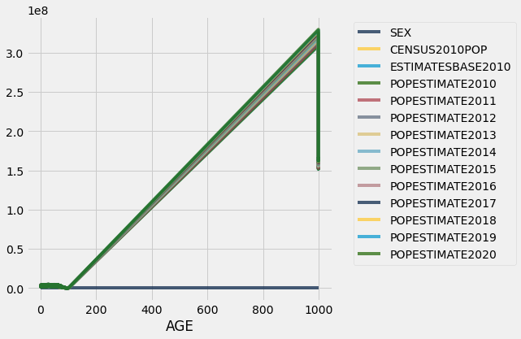

```python
# :(
full.plot('AGE')
```

Visualize the distribution of of population size for both males and females.

```python
males = no_999.where('SEX', 1).drop('SEX')
females = no_999.where('SEX', 2).drop('SEX')
pop_2019 = Table().with_columns(
    'Age', females.column('AGE'),
    'Males', males.column('2019'),
    'Females', females.column('2019'),
)
pop_2019
```

| Age | Males | Females |
| --- | --- | --- |
| 100 | 23531 | 76911 |
| 99 | 14486 | 42288 |
| 98 | 23438 | 62429 |
| 97 | 32616 | 84349 |
| 96 | 45950 | 111294 |
| 95 | 61958 | 145012 |
| 94 | 81689 | 182107 |
| 93 | 103256 | 217066 |
| 92 | 131517 | 262185 |
| 91 | 160753 | 306027 |

... (91 rows omitted)

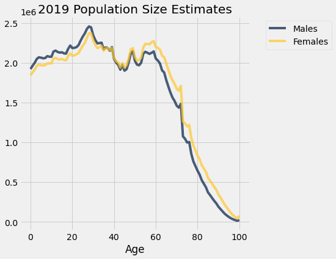

```python
pop_2019.plot('Age')
plots.title('2019 Population Size Estimates')
plots.show()
```

Calculate the percent female for each age

```python
total = pop_2019.column('Males') + pop_2019.column('Females')
percent_female = pop_2019.column('Females') / total * 100
percent_female
```

```
array([76.57254933, 74.48479938, 72.70429851, 72.11473518, 70.77789932,
       70.06426052, 69.03326813, 67.76493653, 66.59478489, 65.56129226,
       64.36264302, 63.42875214, 62.43469375, 61.50555207, 60.61994754,
       59.77448788, 59.12037315, 58.2875019 , 57.64539476, 57.03744511,
       56.3748233 , 56.17047137, 55.82854715, 55.26819948, 54.83251151,
       54.58073446, 54.25448772, 53.9509406 , 53.51022877, 53.44223716,
       53.40722561, 53.27081102, 53.26468499, 53.03484444, 52.92230043,
       52.76149769, 52.44314993, 52.31329221, 52.09723728, 51.88456258,
       51.72648051, 51.46437873, 51.53410868, 51.37238838, 51.2696241 ,
       51.13627062, 50.89138769, 50.81894266, 50.80649435, 50.63449931,
       50.56911629, 50.44489454, 50.61870656, 50.57544456, 50.64261911,
       50.48253869, 50.27570341, 50.36508359, 50.37327215, 50.20977831,
       50.1409379 , 49.89892133, 50.08019625, 49.99258886, 49.88801204,
       49.7823678 , 49.57328862, 49.39653681, 49.34690992, 49.33570713,
       49.27161137, 49.23311185, 49.115004  , 48.84567382, 48.68996749,
       48.76311842, 48.77220901, 48.84655675, 48.95129043, 48.89699809,
       48.8800806 , 48.85555766, 48.94499775, 48.9917086 , 49.00723665,
       48.99213593, 48.95682562, 48.91588355, 48.91848904, 48.96313718,
       48.98425388, 48.96592842, 48.85910586, 48.89552211, 48.89701056,
       48.83289177, 48.88153622, 48.89917454, 48.87032181, 48.90344399,
       48.93979018])
```

Round the values to 3 decimal places so that it's easier to read.

```python
percent_female = np.round(percent_female, 3)
percent_female
```

```
array([76.573, 74.485, 72.704, 72.115, 70.778, 70.064, 69.033, 67.765,
       66.595, 65.561, 64.363, 63.429, 62.435, 61.506, 60.62 , 59.774,
       59.12 , 58.288, 57.645, 57.037, 56.375, 56.17 , 55.829, 55.268,
       54.833, 54.581, 54.254, 53.951, 53.51 , 53.442, 53.407, 53.271,
       53.265, 53.035, 52.922, 52.761, 52.443, 52.313, 52.097, 51.885,
       51.726, 51.464, 51.534, 51.372, 51.27 , 51.136, 50.891, 50.819,
       50.806, 50.634, 50.569, 50.445, 50.619, 50.575, 50.643, 50.483,
       50.276, 50.365, 50.373, 50.21 , 50.141, 49.899, 50.08 , 49.993,
       49.888, 49.782, 49.573, 49.397, 49.347, 49.336, 49.272, 49.233,
       49.115, 48.846, 48.69 , 48.763, 48.772, 48.847, 48.951, 48.897,
       48.88 , 48.856, 48.945, 48.992, 49.007, 48.992, 48.957, 48.916,
       48.918, 48.963, 48.984, 48.966, 48.859, 48.896, 48.897, 48.833,
       48.882, 48.899, 48.87 , 48.903, 48.94 ])
```

Add female percent to our table

```python
pop_2019 = pop_2019.with_column('Percent female', percent_female)
pop_2019
```

| Age | Males | Females | Percent female |
| --- | --- | --- | --- |
| 100 | 23531 | 76911 | 76.573 |
| 99 | 14486 | 42288 | 74.485 |
| 98 | 23438 | 62429 | 72.704 |
| 97 | 32616 | 84349 | 72.115 |
| 96 | 45950 | 111294 | 70.778 |
| 95 | 61958 | 145012 | 70.064 |
| 94 | 81689 | 182107 | 69.033 |
| 93 | 103256 | 217066 | 67.765 |
| 92 | 131517 | 262185 | 66.595 |
| 91 | 160753 | 306027 | 65.561 |

... (91 rows omitted)

Visualize the relationship between age and the percent of the population that is female.

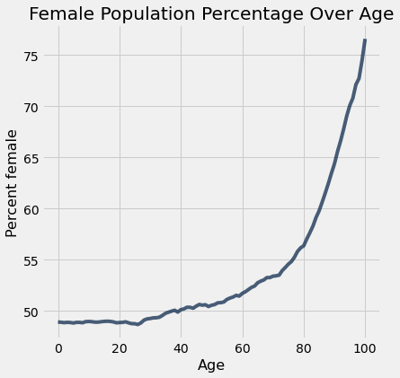

```python
pop_2019.plot('Age', 'Percent female')
plots.title('Female Population Percentage Over Age')
plots.show()
```

Be careful of being visually mislead by the y-axis.

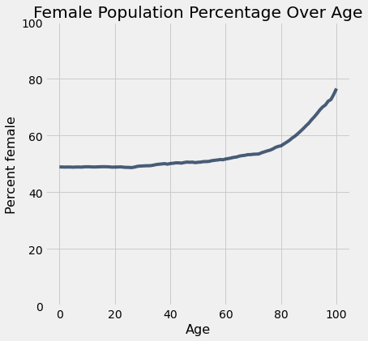

```python
pop_2019.plot('Age', 'Percent female')
plots.ylim(0, 100)
plots.title('Female Population Percentage Over Age')
plots.show()
```